# Reproducible Research: Peer Assessment 1

## Loading and preprocessing the data

First let’s create a sub-directory of our working director to store our data, ./data/

```r
if(!file.exists("./data")){
        dir.create("./data")
}
```

Now we will unzip the activity.zip file (in the working directory) to our *./data/* sub-directory, and look at the contents.

```r
if(!file.exists("./data/activity.csv")){
        unzip("activity.zip", exdir = "./data/", overwrite = FALSE)
}
```

Read the data into R

```r
activity <- read.csv("./data/activity.csv")
```

## What is mean total number of steps taken per day?

First let’s look at the total number of steps taken, per day.

```r
stepsperday <-
        with(activity,
             aggregate(steps~date, FUN = sum))

library(knitr)
kable(head(stepsperday))
```

| date | steps |
| --- | --- |
| 2012-10-02 | 126 |
| 2012-10-03 | 11352 |
| 2012-10-04 | 12116 |
| 2012-10-05 | 13294 |
| 2012-10-06 | 15420 |
| 2012-10-07 | 11015 |

Now let’s view the total steps taken per day as a histogram

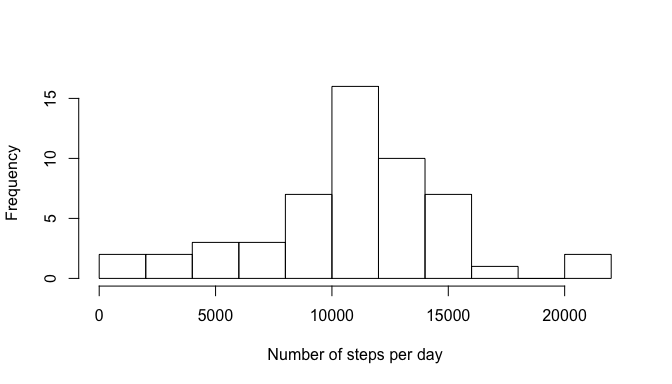

```r
hist(stepsperday$steps, main = "", xlab = "Number of steps per day", breaks = 10)
```

Most days have between 7,000 and 15,000 total steps logged.

Now we’ll calculate and report the mean and median of the total number of steps per day

```r
meansteps <- mean(stepsperday$steps)
mediansteps <- median(stepsperday$steps)
```

- The **mean** is 10,766 per day
- The **median** is 10,765 per day  
  *(rounded values)*

## What is the average daily activity pattern?

First, we’ll calculate the average number of steps for each interval, accross all days

```r
avgStepsPerInterval <-
        with(activity,
             aggregate(steps~interval, FUN = mean))

kable(head(avgStepsPerInterval))
```

| interval | steps |
| --- | --- |
| 0 | 1.7169811 |
| 5 | 0.3396226 |
| 10 | 0.1320755 |
| 15 | 0.1509434 |
| 20 | 0.0754717 |
| 25 | 2.0943396 |

Now we will plot that average number of steps per interval.

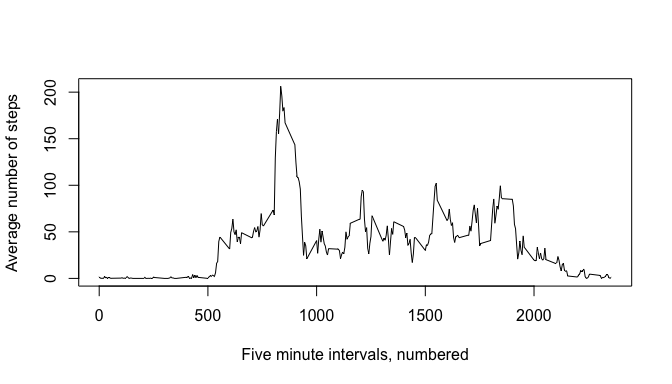

```r
plot(avgStepsPerInterval$interval, avgStepsPerInterval$steps, type = "l",
     ylab = "Average number of steps", xlab = "Five minute intervals, numbered")
```

Now we will calculate which five minute interval, on average, contains the maximum number of steps.

```r
loc <- which.max(avgStepsPerInterval$steps)
maxsteps <-  max(avgStepsPerInterval$steps)
maxinterval <- avgStepsPerInterval$interval[loc]
```

At interval **835**, the average number of steps is highest at, 206 *(rounded)*.

## Imputing missing values

Let’s calculate the number of rows with missing values.

```r
nMissing <- sum(!complete.cases(activity))
```

There are **2304** rows containing missing values.

Now we will add a column to our dataframe, with the average number of steps for each interval. These values will be used to impute the missing values

```r
names(avgStepsPerInterval)[2] <- "avgStepsInt"
activity <- merge(activity, avgStepsPerInterval, by="interval")
```

Now let’s create a new dataset, called *activity1* that is equal to the orginal dataset, but with the missing values filled in.

```r
activity$steps[is.na(activity$steps) == TRUE] <-
        activity$avgStepsInt[is.na(activity$steps)]

library(dplyr)
activity1 <- activity %>%
        select(-avgStepsInt)
```

Now we will redo some of the above calculations on the new dataset.

First let’s look at the total number of steps taken, per day, with the new dataset.

```r
stepsperday1 <-
        with(activity1,
             aggregate(steps~date, FUN = sum))

kable(head(stepsperday1))
```

| date | steps |
| --- | --- |
| 2012-10-01 | 10766.19 |
| 2012-10-02 | 126.00 |
| 2012-10-03 | 11352.00 |
| 2012-10-04 | 12116.00 |
| 2012-10-05 | 13294.00 |
| 2012-10-06 | 15420.00 |

Now let’s view the total steps taken per day as a histogram, with the new dataset.

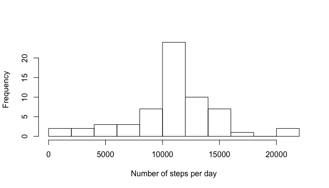

```r
hist(stepsperday1$steps, main = "", xlab = "Number of steps per day", breaks = 10)
```

There is a narrower shape, but it is not notably different.

Now we’ll calculate and report the mean and median of the total number of steps per day

```r
meansteps1 <- mean(stepsperday1$steps)
mediansteps1 <- median(stepsperday1$steps)
```

- The **mean** is 10,766 per day
- The **median** is 10,766 per day  
  *(rounded values)*

Just a very slight difference in these figures with the imputed missing values.

## Are there differences in activity patterns between weekdays and weekends?

First we will add a factor variable *daytype*, which indicates whether each observation occurs on a weekend.

```r
activity1 <- activity1 %>%
        mutate(daytype = as.Date(date)) %>%
        mutate(daytype = weekdays(daytype))

weekendfilter <- activity1$daytype == "Saturday" | activity1$daytype == "Sunday"

activity1$daytype[weekendfilter] <- "weekend"
activity1$daytype[!weekendfilter] <- "weekday"

activity1$daytype <- factor(activity1$daytype)
```

Now, we’ll calculate the average number of steps for each interval, for each weekend days and weekday days.

```r
avgStepsPerInterval1 <-
        with(activity1,
             aggregate(steps~interval+daytype, FUN = mean))

kable(head(avgStepsPerInterval1))
```

| interval | daytype | steps |
| --- | --- | --- |
| 0 | weekday | 2.2511530 |
| 5 | weekday | 0.4452830 |
| 10 | weekday | 0.1731656 |
| 15 | weekday | 0.1979036 |
| 20 | weekday | 0.0989518 |
| 25 | weekday | 1.5903564 |

And finally, we will plot the average number of steps per five minute interval, averaged across weekday days, and weekend days.

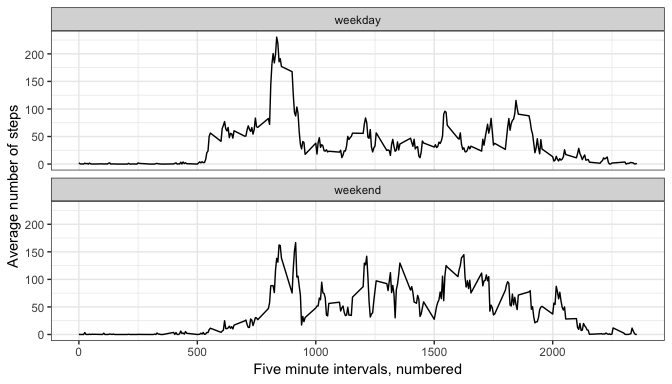

```r
library(ggplot2)

p1 <- ggplot(avgStepsPerInterval1, aes(interval, steps)) +
        geom_line() +
        facet_wrap(~daytype, ncol = 1) +
        theme_bw() +
        ylab("Average number of steps") +
        xlab("Five minute intervals, numbered")
p1
```